# A7-Introducción a series de tiempo. Series estacionarias

Carlos David Lozano Sanguino - A01275316

2023-11-02

# Problema 1

Usa los datos de las ventas de gasolina en una estación de servicio para analizar modelos de pronósticos de la serie de tiempo:

```r
#vector de tiempo
t = 1:12
#valores observados
y = c(17, 21, 19, 23, 18, 16, 20, 18, 22, 20, 15, 22)
```

## Utiliza los métodos de suavizamiento:

- Suavizamiento por promedios móviles

```r
# Utiliza el comando for para el cálculo de los pronósticos y los errores:
# Crear vectores para pronósticos (p) y errores (e)
p <- rep(NA, length(y))
e <- rep(NA, length(y))

# Calcular pronósticos y errores utilizando Promedios Móviles
n <- length(y)
for (i in 1:(n - 3)) {
  p[i + 3] <- (y[i] + y[i + 1] + y[i + 2]) / 3
  e[i + 3] <- p[i + 3] - y[i + 3]}
```

```r
# Crear un data frame con t, y, p y e^2
T <- data.frame(t = t, y = y, p = p, e2 = e^2)

# Calcular el CME sin NA
CME <- mean(T$e2, na.rm = TRUE)

# Imprimir la tabla T y el CME
print(T)
```

```
##     t  y  p e2
## 1   1 17 NA NA
## 2   2 21 NA NA
## 3   3 19 NA NA
## 4   4 23 19 16
## 5   5 18 21  9
## 6   6 16 20 16
## 7   7 20 19  1
## 8   8 18 18  0
## 9   9 22 18 16
## 10 10 20 20  0
## 11 11 15 20 25
## 12 12 22 19  9
```

```r
cat("CME:", CME, "\n")
```

```
## CME: 10.22222
```

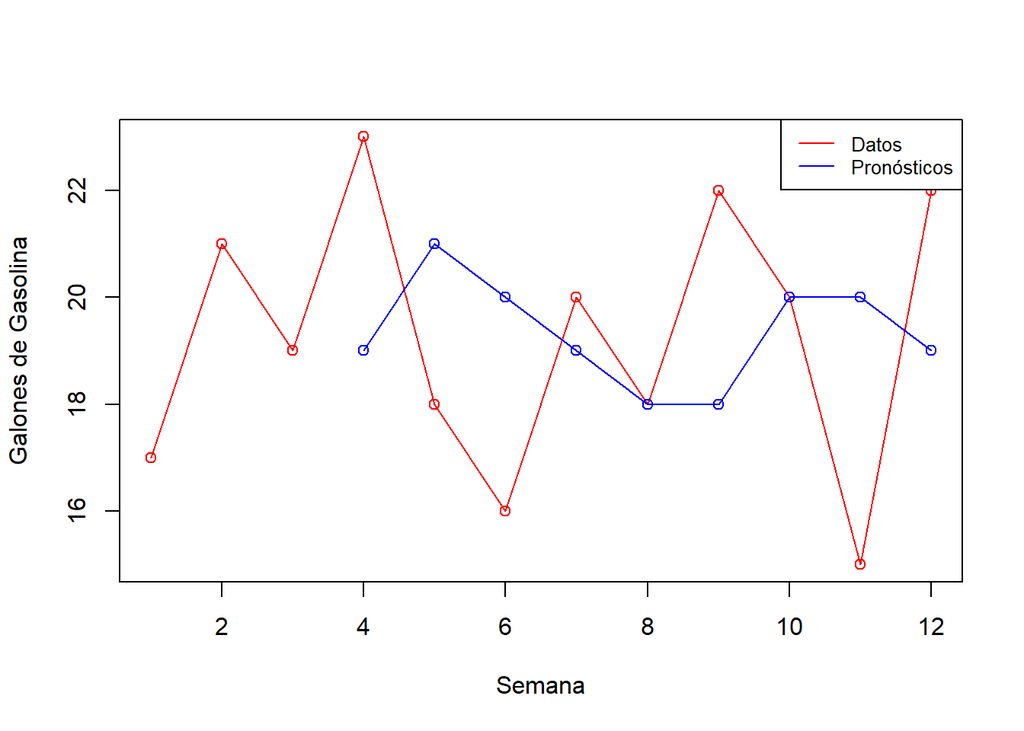

```r
# Graficar los datos de ventas de gasolina y los pronósticos
plot(t, y, type = "o", col = "red", xlab = "Semana", ylab = "Galones de Gasolina")
x <- (3 + 1):n
lines(x, p[x], type = "o", col = "blue")
legend("topright", legend = c("Datos", "Pronósticos"), col = c("red", "blue"), lty = 1, cex = 0.8)
```

- Suavizamiento por promedios móviles ponderados

```r
# Crear vectores para pronósticos (p2) y errores (e2)
p2 <- rep(NA, length(y))
e2 <- rep(NA, length(y))

# Calcular pronósticos y errores utilizando Promedios Móviles Ponderados
n <- length(y)
for (i in 1:(n - 3)) {
  p2[i + 3] <- (1/6) * y[i] + (2/6) * y[i + 1] + (3/6) * y[i + 2]
  e2[i + 3] <- p2[i + 3] - y[i + 3]
}
```

```r
# Crear un data frame con t, y, p2 y e2^2
T2 <- data.frame(t , y , p2 = p2, e2 = e2^2)

# Calcular el CME2 sin NA
CME2 <- mean(T2$e2, na.rm = TRUE)
```

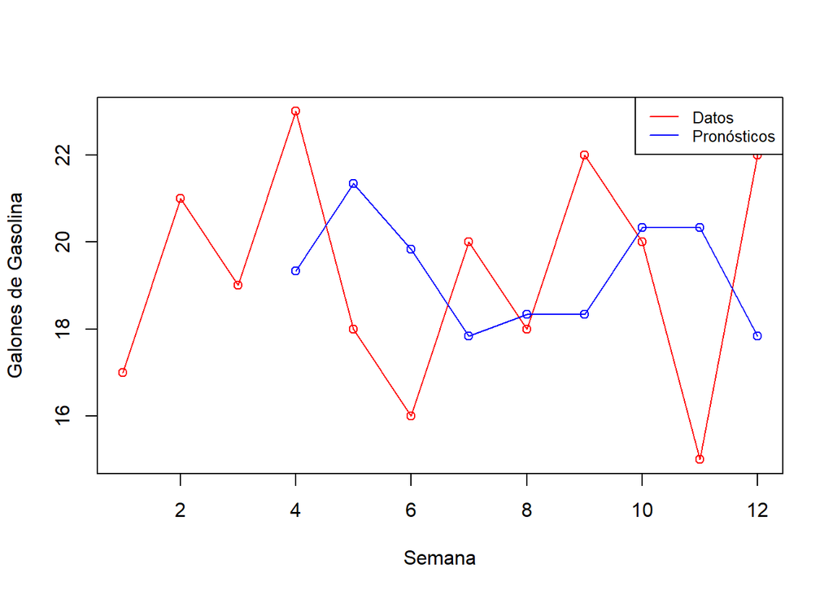

```r
# Graficar los datos de ventas de gasolina y los pronósticos
plot(t, y, type = "o", col = "red", xlab = "Semana", ylab = "Galones de Gasolina")
x <- (3 + 1):n
lines(x, p2[x], type = "o", col = "blue")
legend("topright", legend = c("Datos", "Pronósticos"), col = c("red", "blue"), lty = 1, cex = 0.8)
```

```r
# Imprimir la tabla T2 y el CME2
print(T2)
```

```
##     t  y       p2         e2
## 1   1 17       NA         NA
## 2   2 21       NA         NA
## 3   3 19       NA         NA
## 4   4 23 19.33333 13.4444444
## 5   5 18 21.33333 11.1111111
## 6   6 16 19.83333 14.6944444
## 7   7 20 17.83333  4.6944444
## 8   8 18 18.33333  0.1111111
## 9   9 22 18.33333 13.4444444
## 10 10 20 20.33333  0.1111111
## 11 11 15 20.33333 28.4444444
## 12 12 22 17.83333 17.3611111
```

```r
cat("CME2:", CME2, "\n")
```

```
## CME2: 11.49074
```

- Método de suavizamiento exponencial

```r
# Crear vectores para pronósticos (p3) y errores (e3)
p3 <- rep(NA, length(y))
e3 <- rep(NA, length(y))

# Inicializar los primeros dos valores de p3
p3[1] <- y[1]
p3[2] <- y[1]

# Parámetro de suavizamiento
a <- 0.20

# Calcular pronósticos y errores utilizando Suavizamiento Exponencial
n <- length(y)
for (i in 3:n) {
  p3[i] <- a * y[i - 1] + (1 - a) * p3[i - 1]
  e3[i] <- y[i] - p3[i]
}
```

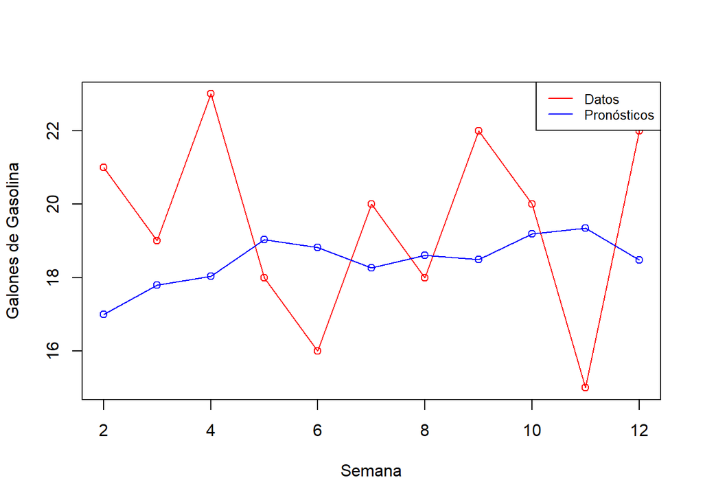

```r
# Crear un data frame con t, y, p3 y e3^2
T3 <- data.frame(t, y, p3, e3 = e3^2)
# Calcular el CME3 sin NA
CME3 <- mean(T3$e3, na.rm = TRUE)
# Graficar los datos de ventas de gasolina y los pronósticos
plot(t[2:n], y[2:n], type = "o", col = "red", xlab = "Semana", ylab = "Galones de Gasolina")
lines(t[2:n], p3[2:n], type = "o", col = "blue")
legend("topright", legend = c("Datos", "Pronósticos"), col = c("red", "blue"), lty = 1, cex = 0.8)
```

```r
# Imprimir la tabla T3 y el CME3
print(T3)
```

```
##     t  y       p3         e3
## 1   1 17 17.00000         NA
## 2   2 21 17.00000         NA
## 3   3 19 17.80000  1.4400000
## 4   4 23 18.04000 24.6016000
## 5   5 18 19.03200  1.0650240
## 6   6 16 18.82560  7.9840154
## 7   7 20 18.26048  3.0259298
## 8   8 18 18.60838  0.3701311
## 9   9 22 18.48671 12.3432263
## 10 10 20 19.18937  0.6571279
## 11 11 15 19.35149 18.9354879
## 12 12 22 18.48119 12.3819951
```

```r
cat("CME3:", CME3, "\n")
```

```
## CME3: 8.280454
```

- Crea un programa que te permita evaluar varios valores de en el método de suavizamiento exponencial hasta encontrar el valor de que minimice el CME.

```r
# Vector de valores de α a evaluar
alphas <- seq(0.01, 1, by = 0.01)

# Vectores para almacenar los resultados
cme_values <- numeric(length(alphas))
predictions <- list()

# Ciclo para evaluar diferentes valores de α
for (i in 1:length(alphas)) {
  p <- rep(NA, length(y))
  e <- rep(NA, length(y))

  p[1] <- y[1]
  p[2] <- y[1]

  for (j in 3:n) {
    p[j] <- alphas[i] * y[j - 1] + (1 - alphas[i]) * p[j - 1]
    e[j] <- y[j] - p[j]
  }

  cme_values[i] <- mean(e^2, na.rm = TRUE)
  predictions[[i]] <- p
}

# Encuentra el valor de α que minimiza el CME
best_alpha <- alphas[which.min(cme_values)]
best_prediction <- predictions[[which.min(cme_values)]]

# Imprime el valor de α que minimiza el CME
cat("Mejor valor de α:", best_alpha, "\n")
```

```
## Mejor valor de α: 0.17
```

```r
# Imprime el CME mínimo
min_cme <- min(cme_values)
cat("CME mínimo:", min_cme, "\n")
```

```
## CME mínimo: 8.256687
```

```r
# Predicción para la semana 13 con el mejor valor de α
next_week_prediction <- best_alpha * y[n] + (1 - best_alpha) * best_prediction[n]
cat("Predicción para la semana 13:", next_week_prediction, "\n")
```

```
## Predicción para la semana 13: 19.07608
```

## Concluye sobre cuál de los modelos usados es el mejor

Podemos concluir que el mejor modelo es el Modelo 3, que corresponde al Suavizamiento Exponencial (CME3 = 8.280454). Esto se debe a que tiene el valor más bajo de CME entre los tres modelos que evaluaste. En el análisis de series de tiempo, un valor de CME más bajo indica que el modelo se ajusta mejor a los datos observados, lo que sugiere que es el modelo más preciso para predecir las ventas de gasolina en función de los datos históricos.

Por lo tanto, el Modelo 3 (Suavizamiento Exponencial) es preferible en este caso debido a su CME más bajo en comparación con los otros modelos.

# Problema 2

Realiza el problema sobre el registro del precio de las acciones (Otros ejemplos de la diapositiva “Series de tiempo estacionarias”).

```r
#Dia
t = c(24,25,26,29,30,1,2,6,7,8,9,12,13,14,15,16)
#Precio
y = c(81.32,81.10,80.38,81.34,80.54,80.62,79.54,79.46,81.02,80.98,80.80,81.44,81.48,80.75,80.48,80.01,80.33)

# Promedio móvil de tres días
n <- length(y)
ma3 <- numeric(n)

for (i in 1:(n-2)) {
  ma3[i+2] <- (y[i] + y[i+1] + y[i+2]) / 3
}

# Pronóstico para el 19 de septiembre
pronostico_ma3 <- ma3[n] # El pronóstico es el valor más reciente del promedio móvil

# Resultados
cat("Pronóstico con Promedio Móvil de Tres Días para el 19 de septiembre:", pronostico_ma3, "\n")
```

```
## Pronóstico con Promedio Móvil de Tres Días para el 19 de septiembre: 80.27333
```

```r
# Parámetro de suavizamiento
alpha <- 0.6

# Suavizamiento exponencial
n <- length(y)
suavizado_exp <- numeric(n)

suavizado_exp[1] <- y[1]
suavizado_exp[2] <- y[1]

for (i in 3:n) {
  suavizado_exp[i] <- alpha * y[i-1] + (1 - alpha) * suavizado_exp[i-1]
}

# Pronóstico para el 19 de septiembre
pronostico_exp <- alpha * y[n] + (1 - alpha) * suavizado_exp[n]

# Resultados
cat("Pronóstico con Suavizamiento Exponencial (α = 0.6) para el 19 de septiembre:", pronostico_exp, "\n")
```

```
## Pronóstico con Suavizamiento Exponencial (α = 0.6) para el 19 de septiembre: 80.31011
```

## Cual de los dos Metodos prefiere y porque?

Para empezar analicemos cada metodo, por un lado el suavizamiento exponencial es más adecuado cuando se espera que los datos tengan tendencias y patrones más complejos, ya que puede adaptarse mejor a cambios recientes. El promedio móvil de tres días suaviza los datos pero no se ajusta a cambios tan rápido como el suavizamiento exponencial, asi que por las ventajas como el adaptarse a los datos y complejidad prefiero el exponencial pero esto cambiara dependiendo del problema si fuera otro en el que no hay tendencias y cambian ciertos parametros eligiria el promedio movil pero en este caso seria el suavizamiento exponencial ya que ofrece ventajas en términos de sensibilidad a los cambios recientes, capacidad de adaptación y flexibilidad a través del parámetro α. Esto lo convierte en una elección preferible cuando se trata de pronosticar los precios de cierre de acciones en un entorno de mercado dinámico y volátil.